# Integrating spectral flow and CyTOF data

Christina Bligaard Pedersen

June 2, 2021

This vignette will demonstrate the integration of spectral flow cytometry (SFC) and CyTOF protein expression measurements using cyCombine.

For this purpose, we will utilize a paired dataset from [Ferrer-Font et al. (2020)](https://doi.org/10.1002/cyto.a.24016). This group studied the comparability of CyTOF and SFC data by using splenocytes from the same samples which had been quantified using the two technologies. They were able to conclude that the results were indeed very similar. However, this analysis was carried out by analyzing the sets separately. Here, we would like to demonstrate the *direct* integration of the sets.

According to the article, the SFC panel of this study contained 21 protein markers, and the CyTOF panel comprised 36 markers. 20 of these were overlapping. A total of five samples are included for each technology, and they are available from FlowRepository (ID: FR-FCM-Z2GZ) or [GitHub](https://github.com/SameOldSamOld/CyTOFAuroraComparison). All files were downsampled to 19,858 cells in the analysis of the article and the uploaded FCS files. We downloaded these and relied on one of the GitHub scripts for accurate mapping of channels and markers.

In the original study, they focused on 11 immune cell populations, which were manually gated. Some of these assignments overlap - i.e. T cells were considered as a combined population and after gating on CD4/CD8. The included populations were “T cells”, “CD4 T cells”, “CD8 T cells”, “DN T cells”, “B cells”, “NK cells”, “Monocytes”, “DCs”, “DC1s”, “DC2s”, and “Neutrophils”. However, the authors have not shared the cell labels in their FCS files, so we replicated their gating to the best of our ability.

It was already established that the frequencies of these populations correlated nicely between the two technologies, however the article also states that they were unable to overlay the two data types due to the different data structures of the platforms. With this in mind, we enter the path of cyCombine.

We start by loading some packages:

```r
library(cyCombine)
library(tidyverse)
```

# Loading data

## Spectral flow cytometry data

We are now ready to load the spectral flow data. We have set up a panel file in csv format, so the correct information is extractable from there. Let us have a look at the contents:

```r
# Directory with raw .fcs files
data_dir <- "FR-FCM-Z2GZ/SFC/"

# Panel and reading data
sfc_panel <- read_csv(paste0(data_dir, "/panel_sfc.csv"))
sfc_panel
```

| Channel | Marker | Type |
| --- | --- | --- |
| FSC-A | FSC-A | none |
| FSC-H | FSC-H | none |
| FSC-W | FSC-W | none |
| SSC-A | SSC-A | none |
| SSC-H | SSC-H | none |
| SSC-W | SSC-W | none |
| FJComp-AF-A | FJComp-AF-A | none |
| FJComp-APC-A | KLRG1 | type |
| FJComp-APC-Fire 750-A | CD45 | type |
| FJComp-Alexa Fluor 532-A | FoxP3 | type |

[output cut: 20 more lines]

We then progress with reading the spectral flow dataset and converting it to a tibble format, which is easy to process. We use cofactor = 6000 for spectral flow data asinh-transformation as suggested by the original study. Because the FCS files do not contain the marker descriptions we specify these based on the `sfc_panel` object we prepared.

```r
# Extract the markers to keep
sfc_markers <- sfc_panel %>%
  dplyr::filter(Type != "none") %>%
  pull(Marker) %>%
  str_remove_all("[ _-]")

# Read fcs files and convert to tibble
spectral <- prepare_data(data_dir = data_dir,
                         metadata = paste0(data_dir, "../metadata.xlsx"),
                         sample_ids = 'SampleID',
                         filename_col = "FileName",
                         batch_ids = "Batch",
                         cofactor = 6000,
                         derand = FALSE,
                         markers = sfc_markers,
                         down_sample = FALSE,
                         panel = sfc_panel,
                         panel_channel = 'Channel',
                         panel_antigen = 'Marker')
```

```
Reading 5 files to a flowSet..
```

```
Extracting expression data..
```

```
Your flowset is now converted into a dataframe.
```

```
Transforming data using asinh with a cofactor of 6000..
```

```
Done!
```

## CyTOF data

We are now ready to load the CyTOF data. Once again, let us have a look at the panel - we also need it here to make our file reading a bit easier.

```r
# Directory with raw .fcs files
data_dir <- "FR-FCM-Z2GZ/CyTOF/"

# Panel and reading data
cytof_panel <- read_csv(paste0(data_dir, "/panel_cytof.csv"))
cytof_panel
```

| Channel | Marker | Type |
| --- | --- | --- |
| Time | Time | none |
| Event_length | Event_length | none |
| Y89Di | 89Y | none |
| Pd102Di | 102Pd | none |
| Rh103Di | 103Rh | none |
| Pd104Di | 104Pd_CD45_PBS | none |
| Pd105Di | 105Pd | none |
| Pd106Di | 106Pd | none |
| Pd108Di | 108Pd | none |
| Pd110Di | 110Pd_CD45_CpG | none |

[output cut: 52 more lines]

And then for the FCS reading and conversion to tibble format. We will employ derandomization and asinh-trasnformation with cofactor = 5.

```r
# Extract the markers to keep
cytof_markers <- cytof_panel %>%
  dplyr::filter(Type != "none") %>%
  pull(Marker) %>%
  str_remove_all("[ _-]")

# Read fcs files and convert to tibble
cytof <- prepare_data(data_dir = data_dir,
                      metadata = paste0(data_dir, "../metadata.xlsx"),
                      sample_ids = 'SampleID',
                      filename_col = "FileName",
                      batch_ids = "Batch",
                      cofactor = 5,
                      derand = TRUE,
                      markers = cytof_markers,
                      down_sample = FALSE,
                      panel = cytof_panel,
                      panel_channel = 'Channel',
                      panel_antigen = 'Marker')
```

```
Reading 5 files to a flowSet..
```

```
Extracting expression data..
```

```
Your flowset is now converted into a dataframe.
```

```
Transforming data using asinh with a cofactor of 5..
```

```
Done!
```

# Batch correction

Next, we need to figure out which markers to use when integrating the two datasets. From the publication, we know that the overlap is 20 markers - let’s verify that to make sure naming matches 1:1.

```r
intersect(sfc_markers, cytof_markers)
```

```
 [1] "KLRG1" "CD45"  "FoxP3" "F480"  "CD8a"  "CD11b" "Ki67"  "CD3e"  "Ly6C"
[10] "CD161" "Ly6G"  "CD11c" "CD45R" "XCR1"  "CD44"  "CD279" "CD274" "CD4"
[19] "CD69"  "MHCII"
```

Now, we are ready to combine the two datasets on the overlapping columns.

```r
# Get overlapping column names
overlap_cols <- intersect(colnames(spectral), colnames(cytof))

# Make one tibble
uncorrected <- bind_rows(cytof[,overlap_cols], spectral[,overlap_cols]) %>%
  mutate(id = 1:(nrow(cytof)+nrow(spectral)))
```

And now, batch correction can be performed with cyCombine. We use rank for normalization because these are data from two different technologies so they are likely to have more different distributions, and ranking is more appropriate in such cases.

```r
# Run batch correction
corrected <- uncorrected %>%
  batch_correct(xdim = 8,
                ydim = 8,
                norm_method = 'rank',
                ties.method = 'average',
                seed = 9369)
```

# Evaluating performance

We now evaluate the correction using EMD - each marker is evaluated across all cells.

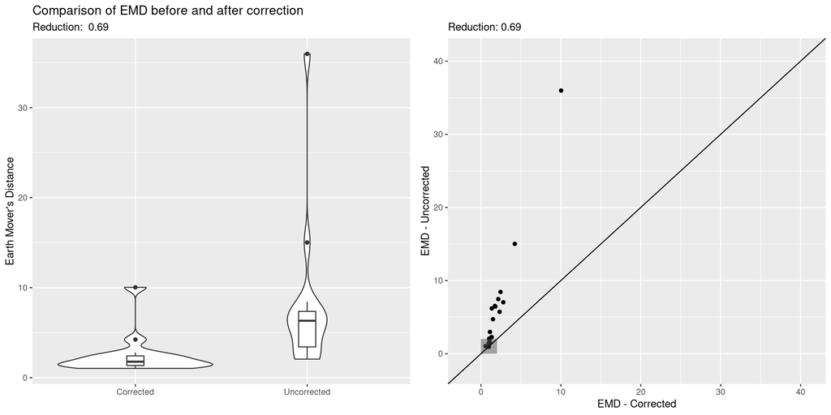

```r
corrected$label <- uncorrected$label <- 1 # We set all labels to 1 in order to evaluate globally

emd <- evaluate_emd(uncorrected = uncorrected,
                    corrected = corrected)

cowplot::plot_grid(emd$violin, emd$scatterplot)
```

We also use the MAD score for evaluation.

```r
# MAD
mad <- uncorrected %>%
  cyCombine::evaluate_mad(corrected,
                          filter_limit = NULL)

cat('The MAD score is: ', mad$score, '\n')
```

```
The MAD score is:  0.07
```

Finally, let us look at some plots to visualize the correction. First, the marker distributions before and after:

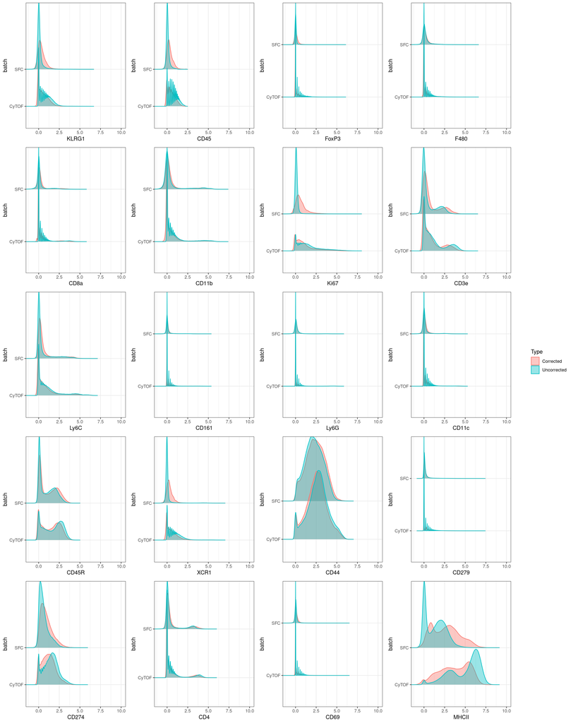

```r
plot_density(uncorrected, corrected, ncol = 4)
```

Finally, some UMAPs to visualize the correction. I will downsample to 10,000 cells from each dataset so it is easier to see what is going on.

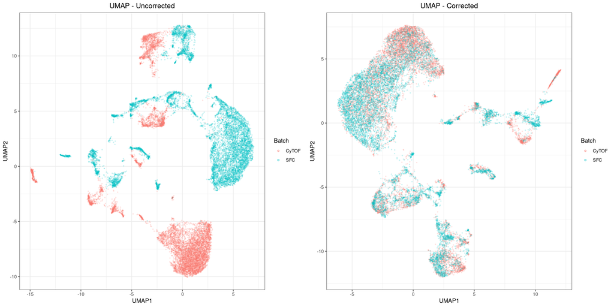

```r
inds <- split(1:length(uncorrected$batch), uncorrected$batch)
sample <- unlist(lapply(inds, sample, 10000))

plot1 <- plot_dimred(uncorrected[sample,], name = 'Uncorrected', type = 'umap')
plot2 <- plot_dimred(corrected[sample,], name = 'Corrected', type = 'umap')

cowplot::plot_grid(plot1, plot2)
```

When studying the plots it is apparent that the datasets from the two platforms are much more comparable after batch correction. The two data types occupy the same regions of the UMAP to a much larger extent post-correction.